# Cornwall Coast Walk — Stats

Auto-generated from the daily trip log

## Reading the log

`walk_stats.csv` is whatever comes straight out of an “export sheet as CSV” from the trip spreadsheet — title row, formula columns, the lot. This document only trusts the *raw* input columns (date, swims, spend by category, distance) and recomputes everything else itself, so nothing here depends on a spreadsheet formula being right.

84 days logged, 2026-07-16 to 2026-11-06.

## Derived columns

7-day averages use a right-aligned window that shortens at the start of the trip (day 3’s “7-day average” is really just the average of days 1–3) — matching the convention already used in the spreadsheet.

## Headline numbers

These get written out as JSON for the site’s stat cards, so the numbers on the page match this report exactly.

| Metric | Value |
| --- | --- |
| Total distance | 2110.4 km |
| Average per day | 25.1 km |
| Total swims | 101 |
| Total spend | £945.81 |
| Average spend / day | £11.26 |

## Distance

```
[1] "2026-07-30" "2026-08-12"
[1] "2026-08-29" "2026-09-05"
[1] "2026-10-25" "2026-11-01"
```

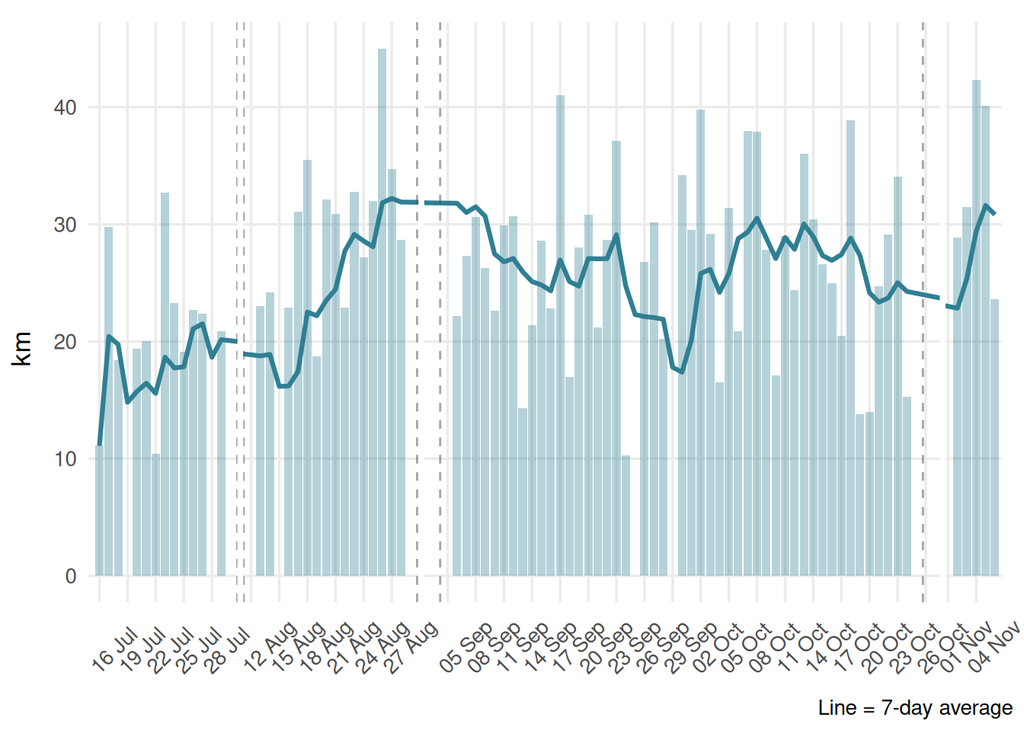

```
[1] "2026-07-30" "2026-08-12"
[1] "2026-08-29" "2026-09-05"
[1] "2026-10-25" "2026-11-01"
```

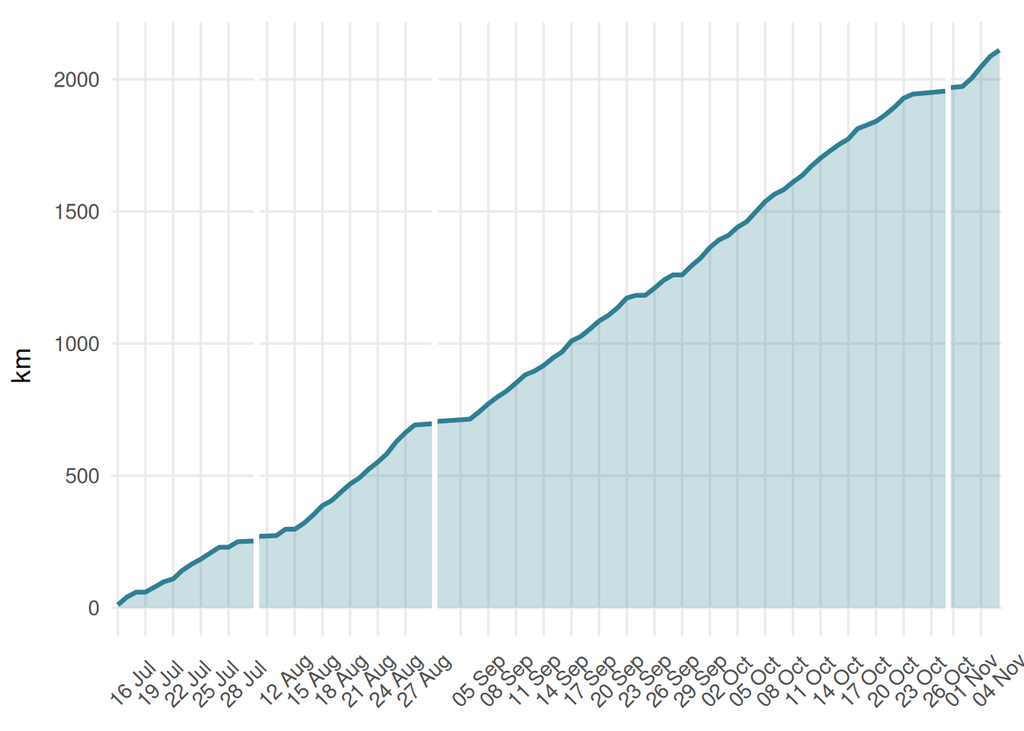

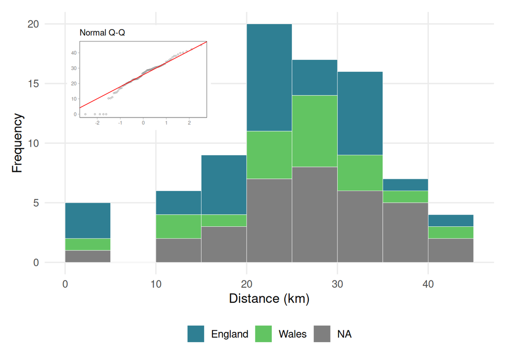

## Spend

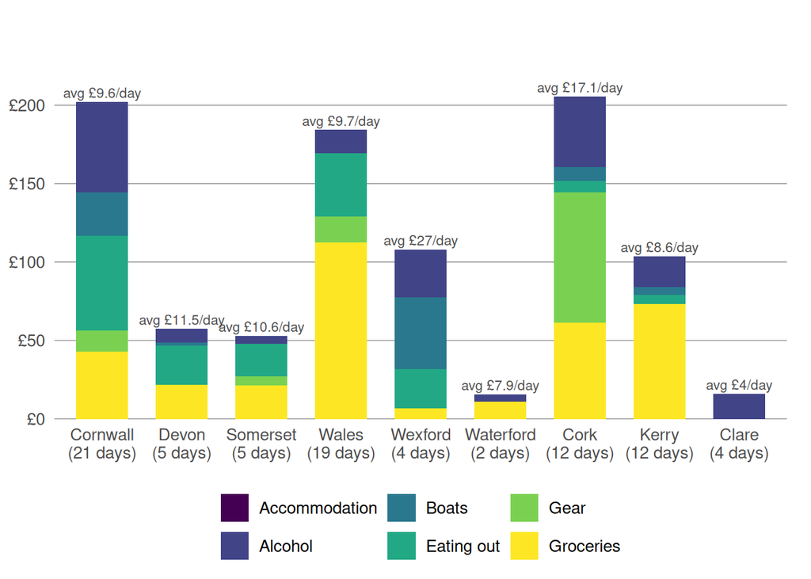

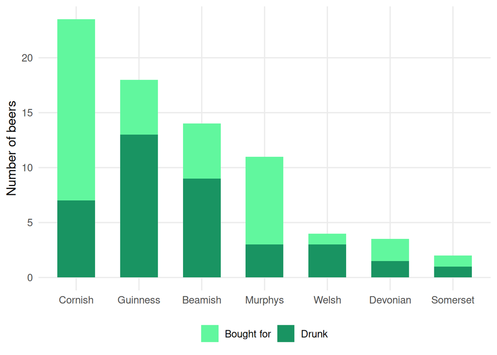

## Swims

```
[1] "2026-07-30" "2026-08-12"
[1] "2026-08-29" "2026-09-05"
[1] "2026-10-25" "2026-11-01"
```

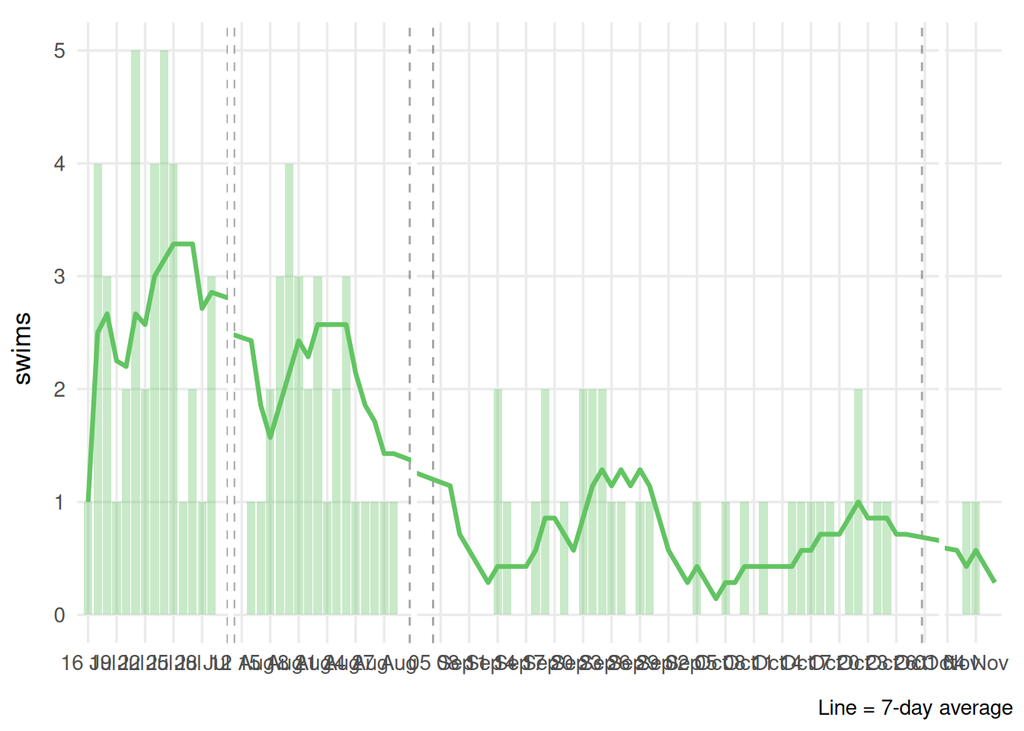

```
[1] "2026-07-30" "2026-08-12"
[1] "2026-08-29" "2026-09-05"
[1] "2026-10-25" "2026-11-01"
```

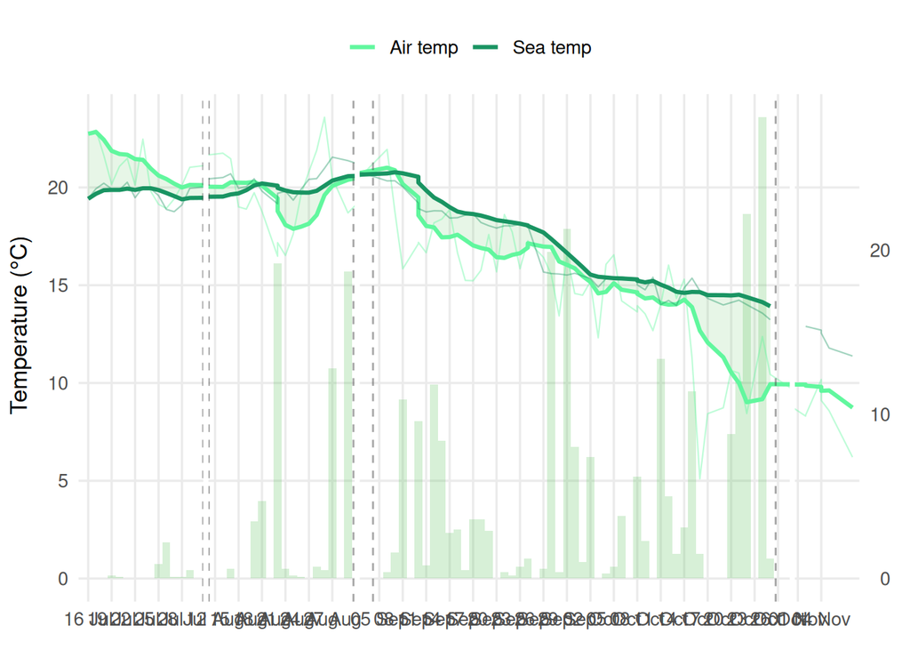

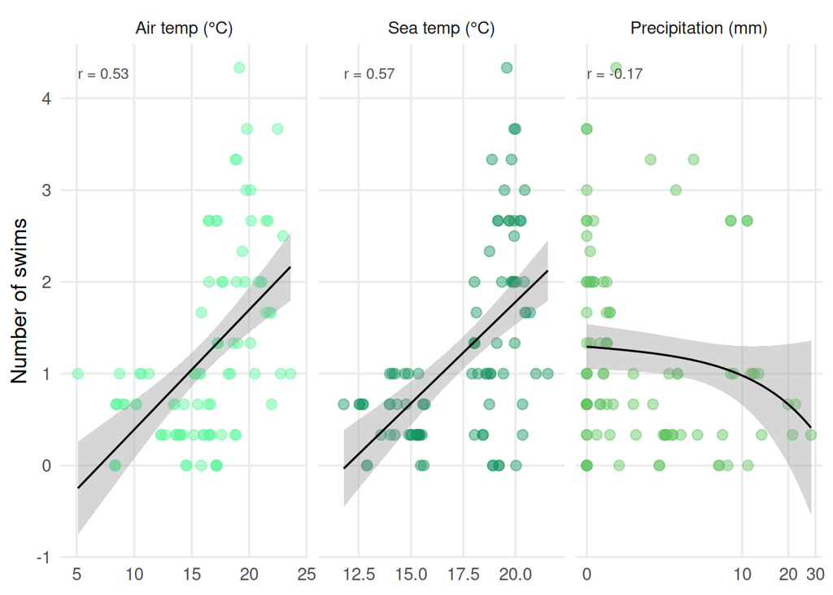

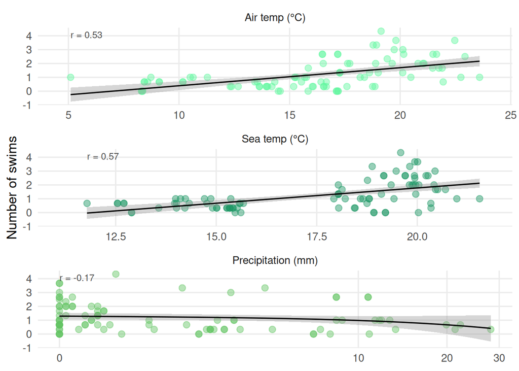

[interactive chart not shown]

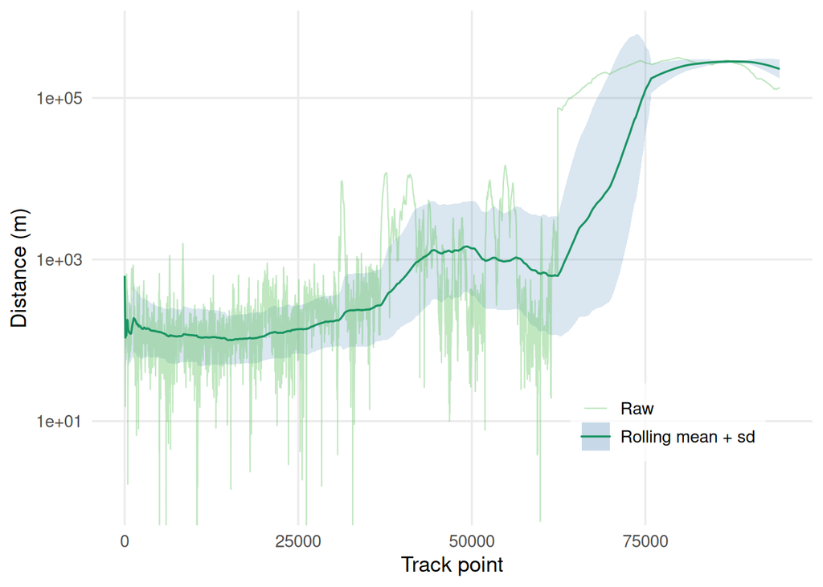

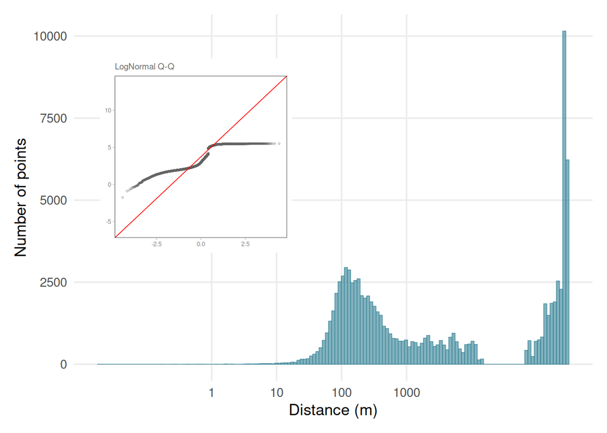

Want to try this with your own walk? Try the interactive tool

*Rendered automatically by GitHub Actions whenever `data/walk_stats.csv` is updated — see `.github/workflows/render_stats.yml`. Edit this file directly to add or change charts; the site pulls the images anddata/walk_stats_summary.json` this produces, not this rendered page.*